# Inferencia de Zr en basaltos: modelo log-normal

Unidad 2 · Estadística inferencial · Geoquímica de rocas con datos de EarthChem PetDB

Cristoffer Rumiguano, Ana Gabriela Fernández, Evelyn Bustamante, Jessica Haro, Jhonattan Ligña

Noviembre de 2026

> Proyecto estrictamente académico (Estadística y Probabilidades, FIGEMPA – UCE). Datos: EarthChem PetDB (CC BY 4.0), descargados el 13/10/2026. Web del proyecto: https://crisrumiguano-art.github.io/geoquimica-earthchem-ml/

## 1. Carga de datos

La inferencia se hace con la **muestra aleatoria simple** de la Lección 3: 1 061 porciones de roca sorteadas de las 159 760 de la base (semilla 2026). Con la base entera, el test de chi-cuadrado rechaza cualquier modelo por diferencias mínimas; con una muestra aleatoria mide lo que importa.

**Población, marco muestral y muestra.** La población (U) son todas las porciones de roca de la corteza y del manto superior de la Tierra: es infinita y nunca se conoce. El **marco muestral** es la base EarthChem PetDB (159 760 porciones de roca registradas): la lista de la que se sorteó la muestra. Por eso, en rigor, la inferencia vale para la población que representa la base, con su sesgo hacia las rocas oceánicas (Lección 3). Al final, la base completa sirve para **validar el método**: si el intervalo calculado con la muestra contiene el valor del marco, el procedimiento funcionó.

```r
knitr::opts_chunk$set(echo = TRUE, message = FALSE, warning = FALSE, fig.align = "center")
library(MASS)          # fitdistr(): estima los parámetros del modelo (viene con R)
dir.create("data/muestras", recursive = TRUE, showWarnings = FALSE)
if (!file.exists("data/muestras/muestra_aleatoria.csv")) {
  download.file("https://github.com/crisrumiguano-art/geoquimica-earthchem-ml/raw/main/data/muestras/muestra_aleatoria.csv", "data/muestras/muestra_aleatoria.csv", mode = "wb")
}
muestra <- read.csv("data/muestras/muestra_aleatoria.csv", check.names = FALSE)
dim(muestra)           # filas y columnas
```

```
## [1] 1061   76
```

## 2. Tabla de distribución de cantidad

Se toma Zr de las **rocas volcánicas máficas** (basaltos y afines) de la muestra. Mezclar todos los tipos de roca da una distribución con varios picos que ningún modelo simple describe. Como en la plantilla del curso, los valores atípicos (regla de la caja) quedan fuera del ajuste: el modelo describe a los basaltos típicos. No se borran de la base y se informan aquí.

```r
x <- muestra[["Zr (ppm)"]]
tipo <- muestra[["Sample Type"]]
x <- x[tipo == "igneous:volcanic:mafic" & !is.na(x) & x > 0]   # basaltos con dato
caja <- boxplot(x, plot = FALSE)                       # límites de la caja (bigotes)
atipicos <- x[x < caja$stats[1] | x > caja$stats[5]]
x <- x[x >= caja$stats[1] & x <= caja$stats[5]]        # datos para el modelo
c(basaltos_con_dato = length(x) + length(atipicos), atipicos = length(atipicos), para_el_modelo = length(x))
```

```
## basaltos_con_dato          atipicos    para_el_modelo
##               185                 8               177
```

```r
h <- hist(x, plot = FALSE)                             # intervalos de Sturges (como hist() en la plantilla)
Li <- h$breaks[-length(h$breaks)]                      # límites inferiores
Ls <- h$breaks[-1]                                     # límites superiores
ni <- h$counts                                         # frecuencia absoluta
hi <- round(ni / sum(ni) * 100, 2)                     # frecuencia relativa (%)
TDF <- data.frame(Li, Ls, MC = h$mids, ni, hi)
knitr::kable(TDF, caption = "Tabla N° 1: distribución de Zr en basaltos (muestra aleatoria)")
```

Tabla N° 1: distribución de Zr en basaltos (muestra aleatoria)

| Li | Ls | MC | ni | hi |
| --- | --- | --- | --- | --- |
| 0 | 50 | 25 | 17 | 9.60 |
| 50 | 100 | 75 | 59 | 33.33 |
| 100 | 150 | 125 | 47 | 26.55 |
| 150 | 200 | 175 | 32 | 18.08 |
| 200 | 250 | 225 | 13 | 7.34 |
| 250 | 300 | 275 | 9 | 5.08 |

## 3. Gráfica de distribución de cantidad

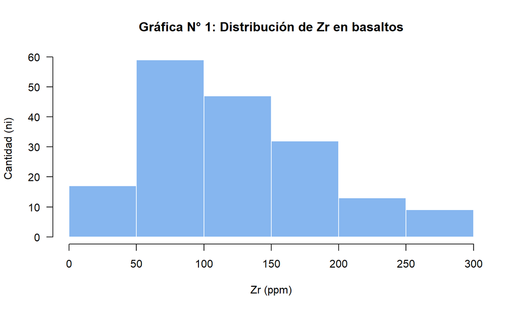

```r
hist(x, breaks = h$breaks, col = "#86b6ef", border = "white", las = 1,
     main = "Gráfica N° 1: Distribución de Zr en basaltos", xlab = "Zr (ppm)", ylab = "Cantidad (ni)")
```

El histograma tiene una cola larga hacia la derecha y no baja de cero: la forma típica de los elementos traza, que se describe con un modelo log-normal (el logaritmo de Zr es normal).

## 4. Conjetura del modelo

Por la forma del histograma se conjetura un **modelo log-normal**. `fitdistr()` estima sus parámetros con los datos (máxima verosimilitud).

```r
ajuste <- fitdistr(x, "lognormal")
ajuste                                                 # parámetros estimados y su error estándar
```

```
##     meanlog       sdlog
##   4.65715793   0.55621338
##  (0.04180756) (0.02956241)
```

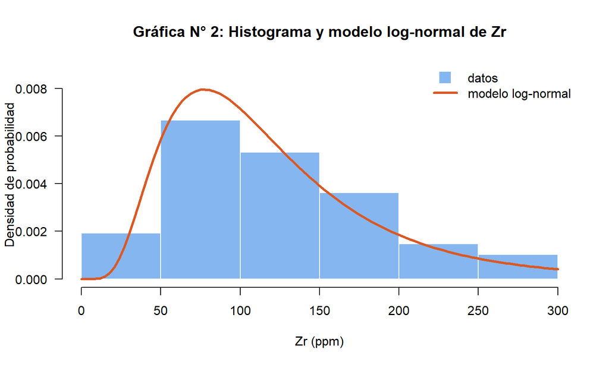

```r
media_log <- ajuste$estimate[["meanlog"]]
desv_log <- ajuste$estimate[["sdlog"]]
techo <- max(h$density, dlnorm(seq(min(x), max(x), length.out = 400), media_log, desv_log)) * 1.1                # alto del gráfico: que entren barras y curva
hist(x, breaks = h$breaks, freq = FALSE, col = "#86b6ef", border = "white", las = 1, ylim = c(0, techo),
     main = "Gráfica N° 2: Histograma y modelo log-normal de Zr", xlab = "Zr (ppm)", ylab = "Densidad de probabilidad")
curve(dlnorm(x, media_log, desv_log), add = TRUE, col = "#d95926", lwd = 3)   # curva del modelo
legend("topright", c("datos", "modelo log-normal"), col = c("#86b6ef", "#d95926"), pch = c(15, NA),
       pt.cex = 2, lwd = c(NA, 3), bty = "n")
```

```r
# Frecuencias observadas (Fo, los datos) y esperadas (Fe, lo que diría el modelo) en cada intervalo
Fo <- ni
P <- plnorm(Ls, media_log, desv_log) - plnorm(Li, media_log, desv_log)                                   # probabilidad de cada intervalo según el modelo
Fe <- P * sum(Fo)
knitr::kable(data.frame(Li, Ls, Fo, Fe = round(Fe, 2)), caption = "Tabla N° 2: frecuencias observadas y esperadas")
```

Tabla N° 2: frecuencias observadas y esperadas

| Li | Ls | Fo | Fe |
| --- | --- | --- | --- |
| 0 | 50 | 17 | 15.96 |
| 50 | 100 | 59 | 65.95 |
| 100 | 150 | 47 | 48.62 |
| 150 | 200 | 32 | 24.43 |
| 200 | 250 | 13 | 11.40 |
| 250 | 300 | 9 | 5.34 |

## 5. Test de aprobación

Dos pruebas, como en la plantilla: la **correlación de Pearson** entre Fo y Fe (si el modelo es bueno, los puntos caen sobre la recta y = x) y el **chi-cuadrado**, que se compara con el umbral de la tabla al 95 % de confianza.

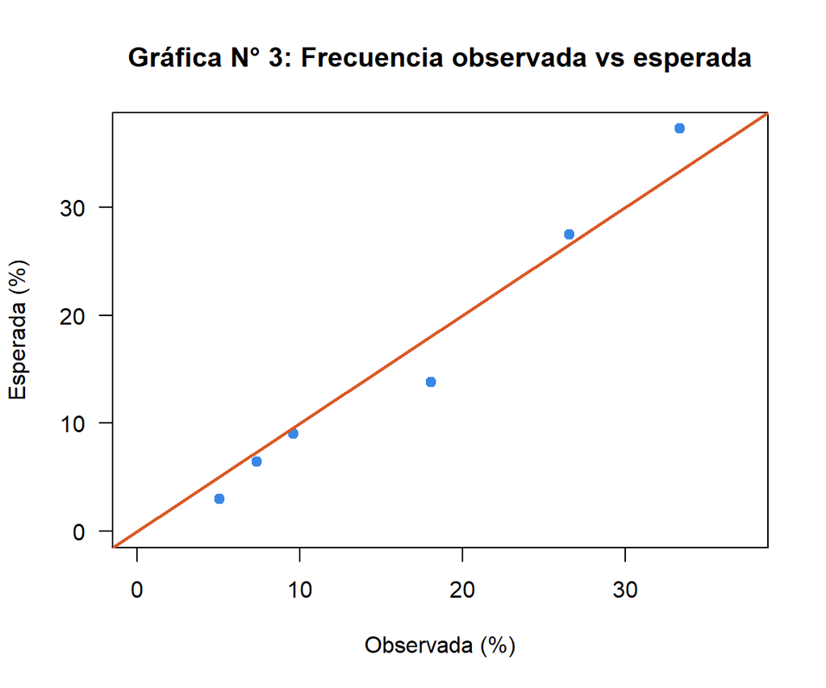

```r
lim <- range(0, Fo / sum(Fo) * 100, Fe / sum(Fo) * 100)   # mismos ejes en x e y
plot(Fo / sum(Fo) * 100, Fe / sum(Fo) * 100, pch = 19, col = "#3987e5", las = 1, xlim = lim, ylim = lim,
     main = "Gráfica N° 3: Frecuencia observada vs esperada", xlab = "Observada (%)", ylab = "Esperada (%)")
abline(a = 0, b = 1, col = "#d95926", lwd = 2)         # recta y = x: ajuste perfecto
```

```r
pearson <- cor(Fo, Fe) * 100                           # en %
gl <- length(Fo) - 1                                   # grados de libertad
x2 <- sum((Fo - Fe)^2 / Fe)                            # chi-cuadrado calculado
umbral <- qchisq(0.95, gl)                             # valor crítico (95 %)
resultado <- ifelse(x2 < umbral, "se acepta el modelo", "se rechaza el modelo")
knitr::kable(data.frame(Variable = "Zr", Pearson = round(pearson, 2), Chi_cuadrado = round(x2, 2),
                        Umbral = round(umbral, 2), Resultado = resultado),
             caption = "Tabla N° 3: pruebas de bondad de ajuste")
```

Tabla N° 3: pruebas de bondad de ajuste

| Variable | Pearson | Chi_cuadrado | Umbral | Resultado |
| --- | --- | --- | --- | --- |
| Zr | 98.79 | 5.93 | 11.07 | se acepta el modelo |

El chi-cuadrado (5.93) es menor que el umbral (11.07): se acepta el modelo. La correlación entre lo observado y lo esperado es de 98.8 %.

## 6. Estimación de probabilidades

**¿Cuál es la probabilidad de que un basalto tenga más de 150 ppm de Zr (basaltos enriquecidos, como los de islas oceánicas)?**

```r
p1 <- 1 - plnorm(150, media_log, desv_log)
p1 * 100                                               # en %
```

```
## [1] 26.2549
```

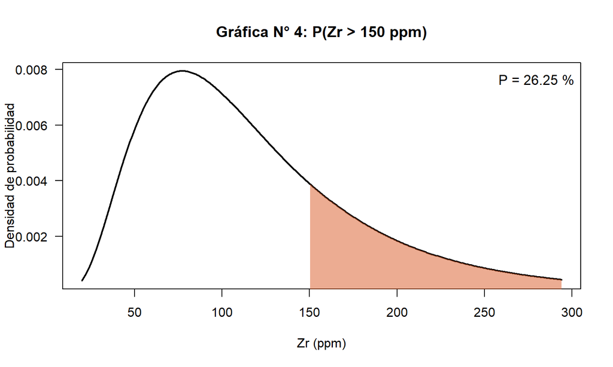

```r
xs <- seq(min(x), max(x), length.out = 400)
plot(xs, dlnorm(xs, media_log, desv_log), type = "l", lwd = 2, las = 1, main = "Gráfica N° 4: P(Zr > 150 ppm)",
     xlab = "Zr (ppm)", ylab = "Densidad de probabilidad")
zona <- xs[xs >= 150]                                    # parte de la curva que se pinta
polygon(c(zona[1], zona, zona[length(zona)]), c(0, dlnorm(zona, media_log, desv_log), 0), col = rgb(0.85, 0.35, 0.15, 0.5), border = NA)
legend("topright", paste0("P = ", round(p1 * 100, 2), " %"), bty = "n", cex = 1.1)
```

**Si se analizan 50 basaltos nuevos, ¿cuántos tendrían entre 50 y 100 ppm de Zr (típico de dorsales)?**

```r
p2 <- plnorm(100, media_log, desv_log) - plnorm(50, media_log, desv_log)
c(probabilidad = p2 * 100, basaltos_esperados_de_50 = p2 * 50)
```

```
##             probabilidad basaltos_esperados_de_50
##                 37.25877                 18.62938
```

## 7. Intervalos de confianza

Intervalo de confianza para la **media poblacional** de Zr en basaltos, con todos los basaltos de la muestra (también los atípicos: aquí no se ajusta un modelo, se estima la media). Por el Teorema del Límite Central, la media de una muestra grande se distribuye normal con error estándar σ/√n; se toma σ = la desviación de la muestra (n grande).

```r
todos <- c(x, atipicos)                                # todos los basaltos con dato
n <- length(todos)
media_m <- mean(todos)
sigma <- sd(todos)
z <- qnorm(0.975)                                      # 1,96 para el 95 %
E <- z * sigma / sqrt(n)                               # error máximo de estimación
IC <- c(inferior = media_m - E, media = media_m, superior = media_m + E)
round(IC, 3)
```

```
## inferior    media superior
##  122.027  138.015  154.004
```

```r
n_necesario <- ceiling((z * sigma / (E / 2))^2)        # tamaño para un error la mitad de grande
n_necesario
```

```
## [1] 741
```

**Validación con el marco muestral.** La media de todos los basaltos de la base sí se puede calcular, porque la base es el marco del que se sorteó la muestra. ¿El intervalo de la muestra la contiene? Es una prueba del método; la media de la población (todos los basaltos de la Tierra) no se conoce.

```r
if (!file.exists("data/earthchem_limpio.csv.gz")) {
  download.file("https://github.com/crisrumiguano-art/geoquimica-earthchem-ml/raw/main/data/earthchem_limpio.csv.gz", "data/earthchem_limpio.csv.gz", mode = "wb")
}
base <- read.csv(gzfile("data/earthchem_limpio.csv.gz", encoding = "UTF-8"), check.names = FALSE)
poblacion <- base[["Zr (ppm)"]]
poblacion <- poblacion[base[["Sample Type"]] == "igneous:volcanic:mafic"]
poblacion <- poblacion[!is.na(poblacion) & poblacion > 0]
media_marco <- mean(poblacion)
c(media_marco = media_marco, dentro_del_intervalo = media_marco >= IC[["inferior"]] & media_marco <= IC[["superior"]])
```

```
##          media_marco dentro_del_intervalo
##             130.8504               1.0000
```

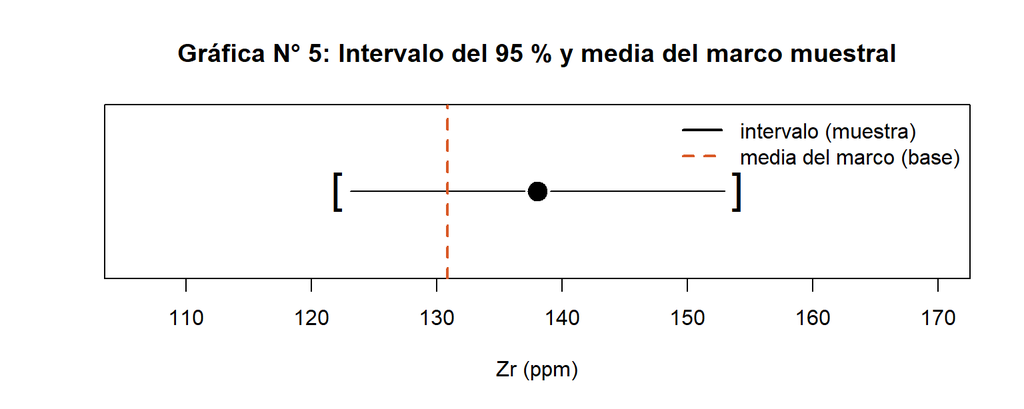

```r
plot(IC, c(1, 1, 1), type = "b", pch = c(91, 19, 93), cex = 2, yaxt = "n", ylab = "", xlab = "Zr (ppm)",
     xlim = range(c(IC, media_marco)) + c(-E, E), main = "Gráfica N° 5: Intervalo del 95 % y media del marco muestral")
abline(v = media_marco, col = "#d95926", lwd = 2, lty = 2)
legend("topright", c("intervalo (muestra)", "media del marco (base)"), col = c("black", "#d95926"),
       lty = c(1, 2), lwd = 2, bty = "n")
```

## 8. Conclusión

El comportamiento de Zr en los basaltos se representa con un **modelo log-normal** de parámetros media logarítmica = 4.657 y desviación logarítmica = 0.556 (chi-cuadrado 5.93 < umbral 11.07; Pearson 98.8 %). El circonio se concentra en pocos basaltos enriquecidos y la mayoría tiene valores bajos. Con el 95 % de confianza, la media poblacional está entre 122.03 y 154 ppm, y la media del marco muestral (130.85, toda la base) cae dentro del intervalo.